# 檢定概念 (1/2)

### Hsin-Chieh Ma

## Statistical hypothesis 統計假設

- 對未知參數 $\theta$ 的推論

### Simple hypothesis:

- 明確指出 $\theta$ 的值
- $H: \theta=\theta_0$

### Composite hypothesis:

- $H: \theta<\theta_0$
- $H: \theta \geq \theta_0$
- $H: \theta_1 \leq \theta \leq \theta_2$

### Alternative hypothesis 對立假設 $H_1$

- 真正關心的事情
- 例如：新藥、新產品
- FDA 要核准新藥需證明藥效比原本的好很多
- $H_0$：新藥藥效沒有比較好
- $H_1$：新藥藥效比較好
- 法官判案
- $H_0$：無罪
- 要有很強的證據顯示有罪才會判有罪
- 設定好 hypothesis 之後，我們需要做實驗
- 產生隨機樣本，定義一個 test

## Test 檢定方法

- 決定是否拒絕虛無假設 ($H_0$) 的規則，決定何時會拒絕 (或不拒絕) $H_0$
- 一個 test 會指明一個隨機樣本的樣本空間中的一個 subset $C$ (critical region)
- test 跟 $C$ 是一體兩面，一個 test 就會對應到一個 $C$
- 如果觀察到的 $(x_1, x_2,..., x_n) \in C$，就拒絕 $H_0$
- 如果觀察到的 $(x_1, x_2,..., x_n) \notin C$，就不要拒絕 $H_0$

## 樣本空間

- $X \sim N(\mu, \sigma^2)\ \ \rightarrow \ X \in R$
- $X \sim Po(\lambda)\ \ \rightarrow \ X \in \lbrace 0, 1, \dots \rbrace$
- $X \sim bin(p)\ \ \rightarrow \ X \in \lbrace 0, 1, \dots \rbrace$
- 對任何 test 而言，都有兩種 error
- 不可能讓兩種錯誤都低，除非 $n$ 趨近於無窮

### Type I error:

- $H_0$ is true but we reject $H_0$
- 嚴重！！！

### Type II error:

- $H_1$ is true but we do not reject $H_0$.
- 該拒不拒

## Power function $\pi_c(\theta)$

- Critical region $C$ 的 power function $\pi_c(\theta)$ ：當 $\theta$ 為真時拒絕 $H_0$ 的機率
- 當 $H_0$ 是對的，希望 $\pi_c(\theta)$ 很小
- 當 $H_1$ 是對的，希望 $1 - \pi_c(\theta)$ 很小

Let $X_1, X_2,..., X_n$ be a random sample and we consider a test with critical region $C$. The power function is

$$\eqalign{\pi_c(\theta) &= P(\ reject\ H_0: \theta\ is\ true)\\ &= P(\ \pmatrix{\ X_1\cr \vdots \cr X_n } \in C: \theta\ is\ true)\\ &= \int\int\dotsi\int f(x_1, x_2,\dots, x_n, \theta)\ dx_1dx_2\dots dx_n}$$

### 例子

- 經過教育改革數年後，我們想要知道在某種特定考試評量上，學生是否表現得比之前好
- $X$ 是表示學生成績的隨機變數，$X$ ~ $N(\ \mu, 100)$
- 過去經驗顯示，$\mu = 75$
- $H_0: \mu \leq 75$
- $H_1: \mu \gt 75$
- 假設我們從 $N(\mu, 100)$ 中獲得一組隨機樣本 $X_1, X_2, \dots, X_{25}$
- 考慮以下兩種 critical region $C$（一般來說我們需自己找 $C$）
- $\bar X > 75$、$\bar X > 78$

### Critical region 1

$$C_1 = \lbrace\ \bar X: \bar X \gt 75 \rbrace = \lbrace\ \pmatrix{X_1 \cr \vdots \cr X_{25}}: \frac{1}{25} \sum_{i=1}^{25} \ X_i \gt 75 \rbrace \subset R^{25}$$

The power function is $$\eqalign{\pi_{c_1}(\mu) = P\ (\ \bar X \gt 75: \mu) &= P\ (\frac{\bar X - \mu}{2} \gt \frac{75 - \mu}{2}) \\ &= P\ (Z > \frac{75 - \mu}{2}) \\ &= 1 - P\ (Z \leq \frac{75 - \mu}{2})}$$

$$X \sim N(\mu, 100)$$ $$\bar X \sim N(\mu, \frac{100}{n}) = N(\mu, \frac{100}{25}=4)$$ $$\frac{\bar X - \mu}{\sigma} = \frac{\bar X - \mu}{2} \sim N(0, 1)$$

$$\eqalign{\pi_{C_1}(75) &= 0.5\\ \pi_{C_1}(77) &= 0.841\\ \pi_{C_1}(79) &= 0.977}$$

- 當 $\mu$ 是 75 時，$H_0$ is true，但我們拒絕 $H_0$ 的機率卻有50%！！

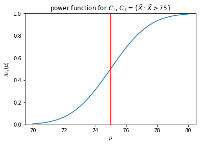

```python
%matplotlib inline
x = np.linspace(70, 80, 1000)
y = 1 - norm.cdf((75 - x)/2)
plt.plot(x, y)
plt.title(r'power function for $C_1$, $C_1 = \lbrace \bar X: \bar X > 75 \rbrace$')
plt.xlabel('$\mu$')
plt.ylabel('$\pi_{C_1}(\mu)$')
plt.axvline(x=75, color='r')
plt.ylim((0, 1))
plt.show()
```

### Critical region 2

$$C_1 = \lbrace\ \bar X: \bar X \gt 78 \rbrace = \lbrace\ \pmatrix{X_1 \cr \vdots \cr X_{25}}: \frac{1}{25} \sum_{i=1}^{25} \ X_i \gt 78 \rbrace \subset R^{25}$$

The power function is

$$\eqalign{\pi_{c_1}(\mu) = P\ (\ \bar X \gt 78: \mu) &= P\ (\frac{\bar X - \mu}{2} \gt \frac{78 - \mu}{2}) \\ &= P\ (Z > \frac{78 - \mu}{2}) \\ &= 1 - P\ (Z \leq \frac{78 - \mu}{2})}$$

$\pi_{C_2}(75) = 0.067$

- 當 $\mu$ 是 75 時，$H_0$ is true，我們拒絕 $H_0$ 的機率只有 0.067，跟 $C_1$ 比起來合理許多。

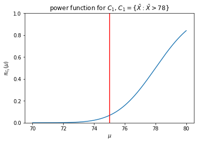

```python
%matplotlib inline
x = np.linspace(70, 80, 1000)
y = 1 - norm.cdf((78 - x)/2)
plt.plot(x, y)
plt.title(r'power function for $C_1$, $C_1 = \lbrace \bar X: \bar X > 78 \rbrace$')
plt.xlabel('$\mu$')
plt.ylabel('$\pi_{C_1}(\mu)$')
plt.axvline(x=75, color='r')
plt.ylim((0, 1))
plt.show()
```

## Size of a test with critical region $C$

- Maximum probability of Type I error
- Size of $C_1$ = $max_{\mu \leq 75} \pi_{C_1}(\mu)$ = 0.5
- Size of $C_2$ = $max_{\mu \leq 75} \pi_{C_2}(\mu)$ = 0.067
- 一般而言，找 critical region 的法則在於先固定一個 significant level $\alpha$，然後在所有 size $\alpha$ 的 test 中找 type II error 最小的。